# Final Project Part 1

Rumi Allbert

April 29, 2021

# Introduction

### Section 1: Harassment at work

#### Question 1: What are the possible responses to this question and how many respondents chose each of these answers?

##### Answer: The possible responses are Does not apply (96), NA (1398), Yes (237), and No (1136)

| harass5 | n |
| --- | --- |
| Does not apply (i do not have a job/superior/co-worker) | 96 |
| No | 1136 |
| Yes | 237 |
| NA | 1398 |

#### Question 2: What percent of the respondents for whom this question is applicable (i.e. excluding NAs and Does not applys) have been harassed by their superiors or co-workers at their job.

##### Answer: 17.26% of respondants for whom the question is applicable answered yes to being harassed by their superiors or co-workers at their job.

| harass5 | n |
| --- | --- |
| No | 1136 |
| Yes | 237 |

```
Answered yes :17.2614712308813%
```

### Section 2: Time spent on email

#### Question 3: Create a new variable called email that combines these two variables to reports the number of minutes the respondents spend on email weekly

##### Answer:

| email |
| --- |
| 720 |
| 30 |
| NA |
| 10 |
| NA |
| 120 |
| 2400 |
| NA |
| 0 |
| NA |

[output cut: 990 more lines]

#### Question 4: Visualize the distribution of this new variable. Find the mean and the median number of minutes respondents spend on email weekly. Is the mean or the median a better measure of the typical among of time Americans spend on email weekly? Why?

##### Answer: I believe that the median would be a better measure because as we can see in the illustration below, the data is skewed, and if we utilize the mean the estimate will be affected the the skew, whereas with the median the skew doesn’t affect the estimate.

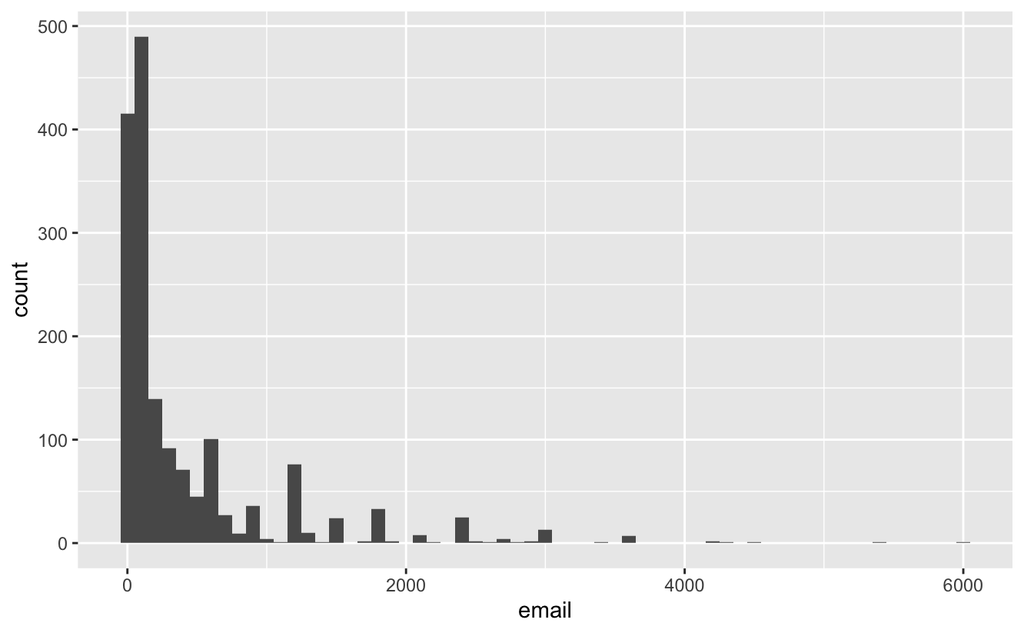

```
[1] 120
[1] 416.8423
```

#### Question 5: Create another new variable, snap_insta that is coded as “Yes” if the respondent reported using any of Snapchat (snapchat) or Instagram (instagrm), and “No” if not. If the recorded value was NA for both of these questions, the value in your new variable should also be NA

##### Answer:

| snap_insta |
| --- |
| NA |
| No |
| No |
| NA |
| Yes |
| Yes |
| NA |
| Yes |
| NA |
| No |

[output cut: 990 more lines]

#### Question 6: Calculate the percentage of Yes’s for snap_insta among those who answered the question, i.e. excluding NAs

##### Answer: The percentage of Ye’s for snap_insta among those who answered the question is 17.93%

```
17.9281478897803%
```

#### Question 7: What are the possible responses to the question Last week were you working full time, part time, going to school, keeping house, or what? and how many respondents chose each of these answers?

##### Answer: The possible responses to the question are: Keeping house (284), Other (89), Retired (574), School (76) , Temp not working (57), Unempl, laid off (118), Working fulltime (1321), Working parttime (345), NA (3)

| wrkstat | n |
| --- | --- |
| Keeping house | 284 |
| Other | 89 |
| Retired | 574 |
| School | 76 |
| Temp not working | 57 |
| Unempl, laid off | 118 |
| Working fulltime | 1321 |
| Working parttime | 345 |
| NA | 3 |

#### Question 8: Fit a model predicting email (number of minutes per week spent on email) from educ (number of years of education), wrkstat, and snap_insta. Interpret the slopes for each of these variables.

##### Answer: One could interpret the slope in words by saying that for every additional year that one spends on education, there will be an increase in the amount of time spent on email weekly, 29.63 minutes more to be exact.

| term | estimate | std.error | statistic | p.value |
| --- | --- | --- | --- | --- |
| (Intercept) | -229.73566 | 149.837100 | -1.5332362 | 1.256904e-01 |
| educ | 29.63249 | 9.600542 | 3.0865433 | 2.108620e-03 |
| wrkstatOther | 33.05657 | 209.470104 | 0.1578105 | 8.746538e-01 |
| wrkstatRetired | 68.27922 | 111.051009 | 0.6148456 | 5.388658e-01 |
| wrkstatSchool | -123.81216 | 143.981393 | -0.8599178 | 3.901424e-01 |
| wrkstatTemp not working | -73.70850 | 153.948487 | -0.4787868 | 6.322468e-01 |
| wrkstatUnempl, laid off | 118.34913 | 151.242215 | 0.7825138 | 4.341895e-01 |
| wrkstatWorking fulltime | 366.84029 | 87.690454 | 4.1833549 | 3.255322e-05 |
| wrkstatWorking parttime | 18.90036 | 101.631637 | 0.1859693 | 8.525252e-01 |
| snap_instaYes | 149.96083 | 52.744807 | 2.8431392 | 4.603431e-03 |

#### Question 9: Create a predicted values vs. residuals plot for this model. Are there any issues with the model? If yes, describe them.

##### Answer:

| .rownames | email | educ | wrkstat | snap_insta | .fitted | .resid | .hat | .sigma | .cooksd | .std.resid |
| --- | --- | --- | --- | --- | --- | --- | --- | --- | --- | --- |
| 2 | 30 | 12 | Working fulltime | No | 492.694487 | -462.6944873 | 0.005447010 | 642.4334 | 2.858547e-04 | -0.7224496418 |
| 6 | 120 | 14 | Keeping house | Yes | 335.079998 | -215.0799979 | 0.017855928 | 642.6293 | 2.076283e-04 | -0.3379400331 |
| 11 | 120 | 12 | Keeping house | No | 125.854194 | -5.8541939 | 0.016459044 | 642.6841 | 1.413866e-07 | -0.0091917477 |
| 13 | 600 | 12 | Working parttime | No | 144.754554 | 455.2454462 | 0.012114986 | 642.4398 | 6.238150e-04 | 0.7132136235 |
| 15 | 30 | 10 | Temp not working | No | -7.119285 | 37.1192854 | 0.048341531 | 642.6825 | 1.783248e-05 | 0.0592497152 |
| 19 | 60 | 18 | Working fulltime | Yes | 820.450244 | -760.4502442 | 0.008087851 | 642.0048 | 1.152611e-03 | -1.1889440495 |
| 21 | 1500 | 12 | Working fulltime | No | 492.694487 | 1007.3055127 | 0.005447010 | 641.4949 | 1.354812e-03 | 1.5728034951 |
| 23 | 60 | 10 | Working parttime | Yes | 235.450405 | -175.4504049 | 0.014363160 | 642.6478 | 1.103518e-04 | -0.2751839686 |
| 28 | 0 | 14 | Working parttime | Yes | 353.980358 | -353.9803578 | 0.011387243 | 642.5365 | 3.539802e-04 | -0.5543617760 |
| 29 | 10 | 18 | Retired | No | 371.928347 | -361.9283466 | 0.017221737 | 642.5289 | 5.663247e-04 | -0.5684889746 |

[output cut: 669 more lines]

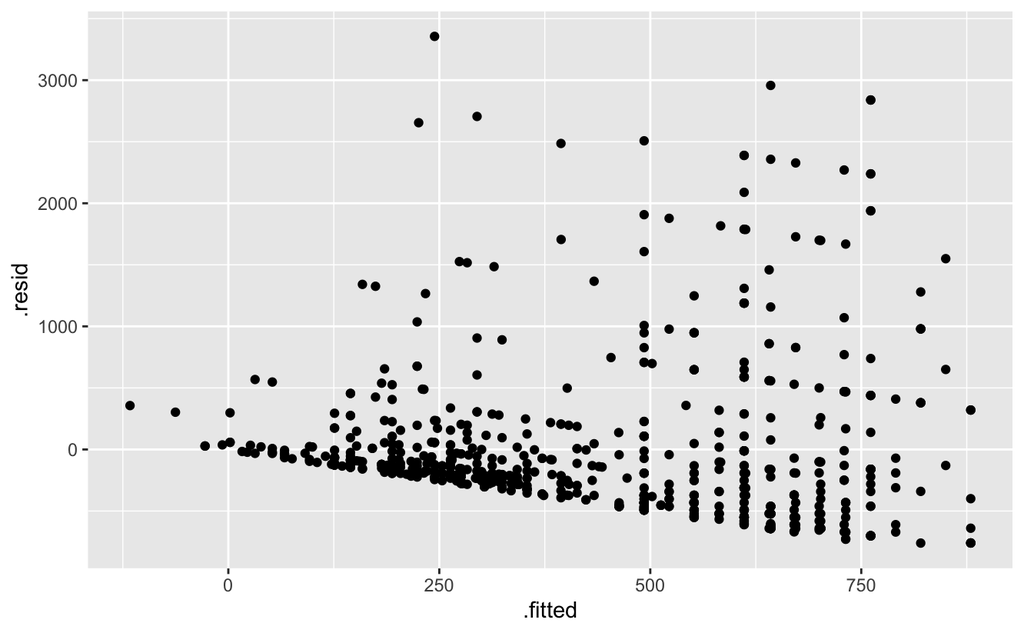

### Section 3: Political views and science research

#### Question 10:

##### Answer:

| harass5 | emailmin | emailhr | educ | polviews | advfront | snapchat | instagrm | wrkstat | email | snap_insta | advscience | simplepolviews |
| --- | --- | --- | --- | --- | --- | --- | --- | --- | --- | --- | --- | --- |
| NA | 0 | 12 | 16 | Moderate | Strongly agree | NA | NA | Working fulltime | 720 | NA | Yes | Moderate |
| NA | 30 | 0 | 12 | Liberal | Disagree | No | No | Working fulltime | 30 | No | No | Liberal |
| No | NA | NA | 16 | Conservative | NA | No | No | Retired | NA | No | NA | Conservative |
| NA | 10 | 0 | 12 | Moderate | Disagree | NA | NA | Working parttime | 10 | NA | No | Moderate |
| No | NA | NA | 18 | Slightly liberal | NA | Yes | Yes | Working parttime | NA | Yes | NA | Liberal |
| NA | 0 | 2 | 14 | Slightly liberal | Strongly agree | No | Yes | Keeping house | 120 | Yes | Yes | Liberal |

#### Question 11: In a new variable, recode polviews such that Extremely liberal, Liberal, and Slightly liberal, are mapped to “Liberal”, and Slghtly conservative, Conservative, and Extrmly conservative disagree are mapped to “Conservative”. The remaining levels can be le as is. Make sure that the levels are in a reasonable order. Don’t overwrite the existing polviews, instead pick a dierent, informative name for your new variable.

##### Answer:

| harass5 | emailmin | emailhr | educ | polviews | advfront | snapchat | instagrm | wrkstat | email | snap_insta | advscience | simplepolviews |
| --- | --- | --- | --- | --- | --- | --- | --- | --- | --- | --- | --- | --- |
| NA | 0 | 12 | 16 | Moderate | Strongly agree | NA | NA | Working fulltime | 720 | NA | Yes | Moderate |
| NA | 30 | 0 | 12 | Liberal | Disagree | No | No | Working fulltime | 30 | No | No | Liberal |
| No | NA | NA | 16 | Conservative | NA | No | No | Retired | NA | No | NA | Conservative |
| NA | 10 | 0 | 12 | Moderate | Disagree | NA | NA | Working parttime | 10 | NA | No | Moderate |
| No | NA | NA | 18 | Slightly liberal | NA | Yes | Yes | Working parttime | NA | Yes | NA | Liberal |
| NA | 0 | 2 | 14 | Slightly liberal | Strongly agree | No | Yes | Keeping house | 120 | Yes | Yes | Liberal |

#### Question 12: Create a visualization that displays the relationship between these two new variables and interpret it

##### Answer:

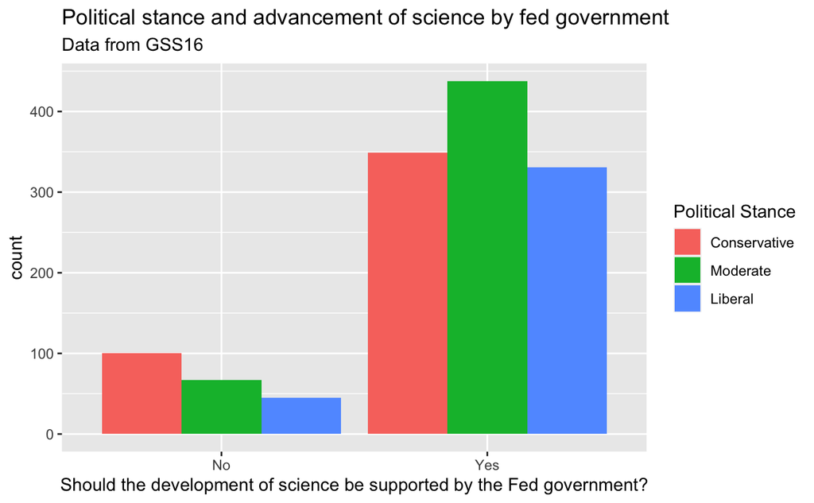

### Section 4: Individual question

#### Question 12: Are ‘high’ education people more liberal or conservative? Visualize the relationship between these variables.

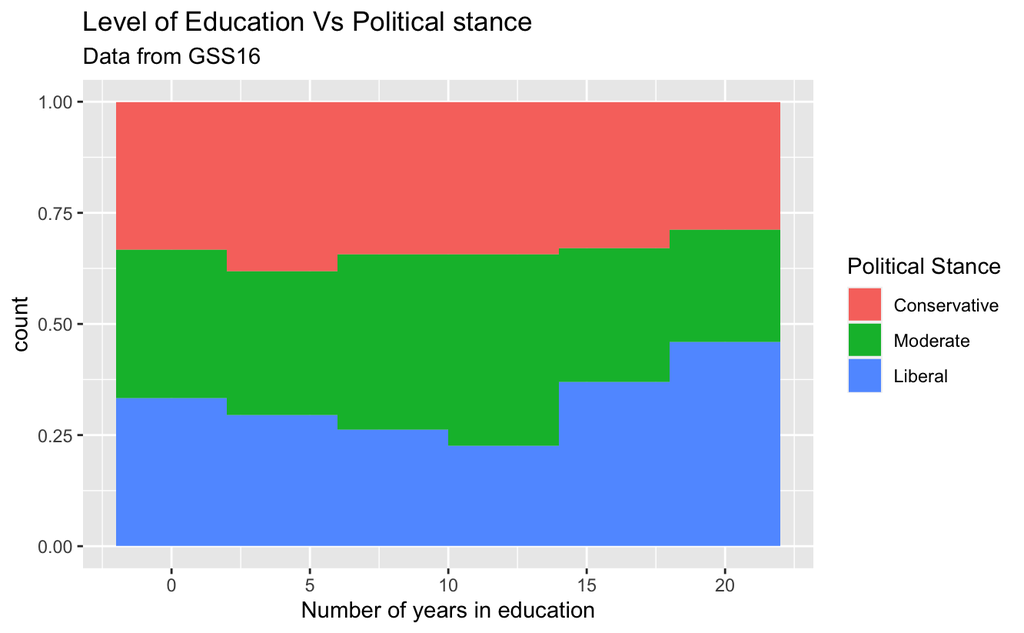